# Examen de prácticas de Computación Numérica

## Ejercicio 1

**(2 puntos)**

Escribir una función **`puntos_medios(x)`** cuyo parámetro de entrada es un vector de puntos equiespaciados y cuyos parámetros de salida son el vector `pm` que contiene los puntos medios entre cada dos puntos de `x` y `todos` que contiene ordenados los puntos de `x`y `pm`.

## Ejercicio 2

**(3 puntos)**

Escribir una función **`dibuja(f,a,b,n)`** que dada una función `f` en un intervalo `[a,b]` y `n` los nodos usados por la regla de trapecio compuesta, dibuja los trapecios cuya área calcula esta regla y la función `f`.

## Ejercicio 3

**(2 puntos)**

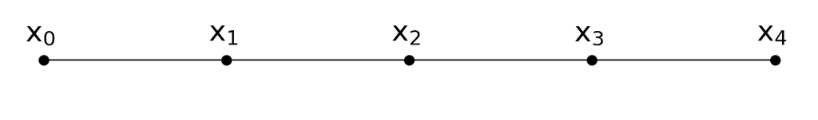

```python
%run puntos
```

La regla del trapecio simple para un intervalo $[x_0,x_4]$

$$\fbox{$I_0 = \frac{h_0}{2}(f(x_0)+f(x_4))$}\quad \mathrm{con}\quad h_0 = x_4-x_0$$

Para dos subintervalos

$$I_1 = \frac{h_1}{2}(f(x_0)+2f(x_2)+f(x_4)) \quad \mathrm{con}\quad h_1 = \frac{h_0}{2}$$

Para cuatro subintervalos

$$I_2 = \frac{h_2}{2}(f(x_0)+2f(x_1)+2f(x_2)+2f(x_3)+f(x_4)) \quad \mathrm{con}\quad h_2 = \frac{h_1}{2}$$

Y así sucesivamente. Como se tiene que

$$I_1 = \frac{h_1}{2}(f(x_0)+f(x_4)) + h_1\,f(x_2)$$

$$I_1 = \frac{1}{2}\frac{h_0}{2}(f(x_0)+f(x_4)) + h_1\,f(x_2)$$

Es decir

$$\fbox{$I_1 = \frac{I_0}{2} + h_1\,f(x_2)$}$$

$$I_2 = \frac{h_2}{2}(f(x_0)+2f(x_2)+f(x_4))+h_2(f(x_1)+f(x_3))$$

$$I_2 = \frac{1}{2}\frac{h_1}{2}(f(x_0)+2f(x_2)+f(x_4))+h_2(f(x_1)+f(x_3))$$

Es decir

$$\fbox{$I_2 = \frac{I_1}{2} + h_2\,(f(x_1)+f(x_3))$}$$

En general

$$\fbox{$I_{k+1} = \frac{I_k}{2} + h_{k+1}\sum f(x_i)$}\qquad (1)$$

Donde los puntos dentro del sumatorio son los puntos nuevos, es decir, los *puntos medios*. Con esta fórmula sólo se evalua la función en cada punto una vez

Escribir una función **`columna_cero(f,a,b,n)`** que calcula la integral aproximada de `f` en el intervalo `[a,b]` con la regla de trapecio compuesta `n` veces:

- `I[0]` es la integral que utiliza solo los nodos `a` y `b`.
- `I[1]` es la integral que utiliza los nodos anteriores más su punto medio (3 puntos).
- `I[2]` es la integral que utiliza solo los nodos anteriores más sus puntos medios (5 puntos).
- `I[3]` es la integral que utiliza solo los nodos anteriores más sus puntos medios (9 puntos).
- Y así sucesivamente.

## Ejercicio 4

**(3 puntos)**

La extrapolación de Richardson es un método para disminuir el error de determinados procedimientos numéricos. Elimina errores, aunque solo puede hacerlo con errores de la forma

$$E(h)= K\,h^p$$

Si usamos

$$h_{k+1}=\frac{h_k}{2}$$

Podemos usar la fórmula

$$I_{i,j}=\frac{4^{\,j}\,I_{i,j-1}-I_{i-1,j-1}}{4^{\,j}-1}$$

para obtener un valor más preciso a partir de los resultados obtenidos en el ejercicio anterior.

Escribir una función **`Romberg(f,a,b,n)`** que obtenga la aproximación mejorada con la fórmula anterior de la integral de la función `f` en el intervalo `[a,b]` a partir de las aproximaciones `n` aproximaciones iniciales con la regla compuesta del trapecio del ejercicio anterior.

Comparar:

- El valor con la regla del trapecio compuesta con $2^{n-1}$ intervalos.
- El valor con la corrección del error.
- El valor exacto.

```
==============  EJERCICIO 1  ==============
x
[0. 1. 2. 3. 4. 5.]
puntos medios
[0.5 1.5 2.5 3.5 4.5]
todos
[0.  0.5 1.  1.5 2.  2.5 3.  3.5 4.  4.5 5. ]

x
[0.  0.5 1.  1.5 2.  2.5 3.  3.5 4.  4.5 5. ]
puntos medios
[0.25 0.75 1.25 1.75 2.25 2.75 3.25 3.75 4.25 4.75]
todos
[0.   0.25 0.5  0.75 1.   1.25 1.5  1.75 2.   2.25 2.5  2.75 3.   3.25
 3.5  3.75 4.   4.25 4.5  4.75 5.  ]

==============  EJERCICIO 2  ==============
```

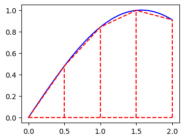

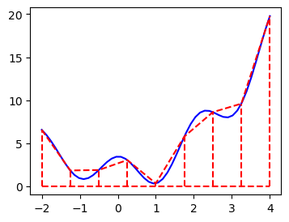

```
==============  EJERCICIO 3  ==============

Primer ejemplo columna cero
[0.909297 1.29612  1.38652  1.408763]

Segundo ejemplo columna cero
[79.020161 40.484373 35.974337 33.158128 32.552785]

==============  EJERCICIO 4  ==============

---- Primer ejemplo Romberg ----

Matriz
[[0.909297 0.       0.       0.      ]
 [1.29612  1.42506  0.       0.      ]
 [1.38652  1.416654 1.416093 0.      ]
 [1.408763 1.416178 1.416146 1.416147]]

Valor con 8 intervalos          1.4087633772340937
Valor con corrección del error  1.416146920716148
Valor exacto                    1.4161468365471424

---- Segundo ejemplo Romberg ----

Matriz
[[79.020161  0.        0.        0.        0.        0.      ]
 [40.484373 27.63911   0.        0.        0.        0.      ]
 [35.974337 34.470992 34.926451  0.        0.        0.      ]
 [33.158128 32.219392 32.069285 32.023934  0.        0.      ]
 [32.552785 32.351004 32.359779 32.36439  32.365725  0.      ]
 [32.404617 32.355227 32.355509 32.355441 32.355406 32.355396]]

Valor con 32 intervalos         32.40461678435753
Valor con corrección del error  32.35539581991169
Valor exacto                    32.35547659093363
```

```python
%run Romberg
```